# Week 3 Homework — Elementary Python Programming

**Name:** Isabella Wollney **NetID:**

## Instructions

- You **may use AI** (ChatGPT, Copilot, etc.) for this course **but** you must be able to **defend and explain** every line you submit.
- Next Thursday, you may be asked to solve / explain one of these on the board (unknown in advance).
- Run the **TESTS** cells. Fix your code until they pass. **assert** just checks one object against another.
- Write **clear** code over clever code.

### Allowed imports

For this homework, **do not import anything** unless a question explicitly allows it.

## Exercise 0 — Sorting without `sorted()` or `.sort()`

Sort algorithms are some of the foundational computer algorithms, and a great way to learn programming is by writing sort functions.

Write a function:

- `selection_sort(values)`

It should return a **new** list containing the elements of `values` in **ascending** order.

Requirements:

- Do **not** use `sorted()` or `list.sort()`.
- Do **not** import anything.
- Assume the input is a list of numbers (int or float)
- Do not modify the input list (treat it as read-only).

Tip: **Selection sort** idea:

1. Find the smallest remaining value
2. Append it to an output list
3. Remove it from the pool of remaining values
4. Repeat

(3 points available)

```python
# TODO
def selection_sort(values):
    """Return a new list with the values sorted ascending (selection sort)."""
    # Your code here
    array = values[:] # makes copies of the values
    n=len(array) # len=length, how many elements are in the array
    for i in range(n): # goes through each position (array) in the list one by one
        min_index = i # assume the first index is the smallest (at position i)
        for j in range(i+1, n): # checks the rest of the array to see if there is a smaller value
            if array[j] < array[min_index]: # is number at position j is smaller than the number at min_index?
                min_index = j # if there is a smaller value, update the index, remember its position
        array[i], array [min_index] = array[min_index], array[i] # swap the values, putting the smallest value at position i
    return array #give back the sorted array, showing smallest to largest

    ...
print (selection_sort([6,8,10,5,2,3,9,1,4,7]))
```

```
[1, 2, 3, 4, 5, 6, 7, 8, 9, 10]
```

```python
# TESTS (Exercise 0)
assert selection_sort([3, 1, 2]) == [1, 2, 3]
assert selection_sort([]) == []
assert selection_sort([5]) == [5]
assert selection_sort([2, 2, 1]) == [1, 2, 2]

# assert means "check that this is true"
# Must not modify input
v = [3, 1, 2]
out = selection_sort(v)
assert v == [3, 1, 2]
assert out is not v
```

## Exercise 1 — Lists and `for` loops

Generate a list of 1000 random integers in the range 0-100 from a uniform distribution using the random.random() function that is built-in to Python. You can also use `range`. But no other built-in Python functions or Python modules can be used (though you can make your own)

Using a for loop, compute the mean, median, minimum, and maximum of the list. Print them out.

Rules:

- Do **not** use `sort`, or `sorted`
- Do **not** use `sum()`, `min()`, `mean()`, 'median()`, or`max()` for this exercise.
- Do **not** use NumPy.

(5 points available)

```python
import numpy as np
nums = np.random.rand(100)
print(nums)
print("Mean:", np.mean(nums))
```

```
[0.29521123 0.64334055 0.12665384 0.95655241 0.39696728 0.34949051
 0.12371506 0.35937839 0.11002054 0.0678148  0.66560901 0.64059979
 0.57859211 0.81675353 0.31090292 0.39888931 0.9216314  0.89919774
 0.55586199 0.09543466 0.00147015 0.1904604  0.51070481 0.92396547
 0.55382999 0.77940454 0.99436514 0.24184    0.34545402 0.54149322
 0.86372474 0.5079786  0.375419   0.15002284 0.49692787 0.21025303
 0.81515367 0.86198247 0.34809983 0.75156623 0.62833653 0.32902715
 0.12902953 0.62908689 0.00960902 0.33882328 0.56687673 0.41501309
 0.78473054 0.90548763 0.53071381 0.16220584 0.27082854 0.59674123
 0.70736258 0.01784915 0.23459728 0.09676546 0.53978271 0.05527848
 0.05987758 0.12244992 0.85826162 0.97477183 0.94450589 0.07248906
 0.52817157 0.03130523 0.04072922 0.1993883  0.34968754 0.92190121
 0.63148066 0.82657367 0.53990439 0.78417151 0.79646705 0.31999688
 0.6256545  0.72160641 0.3108302  0.49635391 0.85081536 0.46713969
 0.74047915 0.15423362 0.55576048 0.11055698 0.16840511 0.75699077
 0.19540977 0.88151621 0.83385014 0.49848597 0.20814962 0.64902251
 0.33266767 0.4019678  0.20599559 0.98714385]
Mean: 0.4788004701489891
```

```python
import random


x = [3, 7, 2, 9, 9, 4, 1] # example list of numbers

# TODO: compute mean_x, min_x, max_x using a for-loop
x = []
for i in range(1000): # 1. Generate 1000 random integers between 0 and 100
    val = int(random.random() * 101) # random.random() generates a float between 0 and 1
    x += [val] # append the generated integer to the list x because we need a list of numbers to compute statistics on

# 2. Compute Mean, Min, and Max using a for-loop
total = 0 # initialize total to 0 for mean calculation
min_val = x[0] # initialize min_val to the first element for min calculation
max_val = x[0] # initialize max_val to the first element for max calculation
count = 0 # initialize count to 0 for mean calculation

for value in x: # iterate through each value in the list x
    total += value # add the current value to total for mean calculation because we need the sum of all elements
    count += 1 # increment count for mean calculation because we need the number of elements
    if value < min_val: # check if the current value is less than min_val for min calculation
        min_val = value
    if value > max_val: # check if the current value is greater than max_val for max calculation
        max_val = value

mean_val = total / count

# 3. Compute Median (Manual Sort - NO sort() or sorted() used)
# We create a copy of the list manually to keep the original intact
x_copy = x[:]
n = 1000

# Bubble Sort Implementation for Median Calculation
for i in range(n):
    for j in range(0, n - i - 1):
        if x_copy[j] > x_copy[j + 1]:
            # Swap if the element found is greater than the next element
            temp = x_copy[j]
            x_copy[j] = x_copy[j + 1]
            x_copy[j + 1] = temp



# 4. Final Median Calculation
# Since n is 1000 (even), we average the two middle values between indices 499 and 500
mid1 = x_copy[499] # shows the value at index 499
mid2 = x_copy[500] # shows the value at index 500
median_val = (mid1 + mid2) / 2

# 5. Print out the results
print("Mean:", mean_val)
print("Median:", median_val)
print("Min:", min_val)
print("Max:", max_val)
```

```
Mean: 50.912
Median: 50.0
Min: 0
Max: 100
```

```python
# TESTS (Exercise 1)
assert abs(mean_x - (3+7+2+9+9+4+1)/7) < 1e-12
assert min_x == 1
assert max_x == 9
```

## Exercise 2 — Functions

Write a function `quadratic(x, a, b, c)` that computes:

$$ f(x) = a x^2 + b x + c $$

Requirements:

- `x` may be a single number (int/float).
- Return a single number, f.

(2 points available)

```python
# TODO

def quadratic(x, a, b, c): # define function quadratic with parameters x, a, b, c
    """Return the value of the quadratic a*x^2 + b*x + c.""" # docstring
    return a*x**2 + b*x + c # return the value of the quadratic equation

print(quadratic(2, 1, 0, 0))
```

```
4
```

```python
# TESTS (Exercise 2)
assert quadratic(2, 1, 0, 0) == 4
assert quadratic(2, 0, 3, 0) == 6
assert quadratic(2, 0, 0, 5) == 5
assert abs(quadratic(1.5, 2, -1, 0.5) - (2*(1.5**2) - 1*1.5 + 0.5)) < 1e-12
```

## Exercise 3 — `while` loops and input validation

Write a function `first_power_of_two_at_least(n)` that returns the **smallest** power of two (1, 2, 4, 8, ...) that is **>= n**.

Examples:

- `n=5` → `8`
- `n=16` → `16`

Requirements:

- If `n` is less than 1, raise a `ValueError`.
- Use a **while** loop.

(3 points available)

```python
# TODO

def first_power_of_two_at_least(n): # define function with parameter n
    """Return the first power of two that is at least n.""" # docstring
    if n < 1: # check if n is less than 1
        raise ValueError("n must be at least 1") # raise error if n is less than 1
    power = 1 # start with 2^0 = 1 because it is the first power of two
    while power < n: # loop until power is at least n because we want the first power of two that is at least n
        power = power * 2 # multiply power by 2 to get the next power of two because powers of two are 1, 2, 4, 8, 16, ...
    return power # return the first power of two that is at least n

print(first_power_of_two_at_least(40))
```

```
64
```

```python
# TESTS (Exercise 3)
assert first_power_of_two_at_least(1) == 1
assert first_power_of_two_at_least(2) == 2
assert first_power_of_two_at_least(3) == 4
assert first_power_of_two_at_least(5) == 8
assert first_power_of_two_at_least(16) == 16
try:
    first_power_of_two_at_least(0)
    raise AssertionError('Expected ValueError')
except ValueError:
    pass
```

## Exercise 4 — 99 Bottles (loops + conditionals + strings)

Write a function `verse(n)` that returns the verse for `n` bottles.

Requirements:

- Use correct grammar for **1 bottle** and **0 bottles**.
- When `n==0`, the verse should include a line that says you should "Go to the store" and it resets to 99.

Then print the full song from 99 down to 0.

Tip: Write a helper function `bottle_phrase(n)` that returns `'1 bottle'` or `'2 bottles'` etc.

(5 points available)

```python
# TODO

def bottle_phrase(n): # define function bottle_phrase with parameter n
    if n == 0: # check if n is 0 because it is a special case
        return "0 bottles" # return "0 bottles" for 0
    elif n == 1: # check if n is 1 because it is another special case
        return "1 bottle" # return "1 bottle" for 1
    else: # for all other cases (n greater than 1)
        return f"{n} bottles" # return "{n} bottles" for n greater than 1


def verse(n): # define function verse with parameter n
    if n > 0: # check if n is greater than 0
        return ( # return the verse for n greater than 0 because it is the general case
            f"{bottle_phrase(n)} of beer on the wall\n" # return "{n} bottles of beer on the wall" for n greater than 1
            f"{bottle_phrase(n)} of beer.\n" # return "{n} bottles of beer." for n greater than 1
            f"Take one down and pass it around, {bottle_phrase(n-1)} of beer on the wall." # return "Take one down and pass it around, {n-1} bottles of beer on the wall." for n greater than 1 because we are taking one down
        )
    elif n == 0: # check if n is 0 because it is a special case
        return ( # return the verse for n equal to 0
            "0 bottles of beer on the wall.\n"
            "Go to the store and buy some more, "
            "99 bottles of beer on the wall."
        )

# Print the whole song
for n in range(99, -1, -1): # start at 99, end at 0 (not -1), in steps of -1 because we are counting down
    print(verse(n)) # print the verse for each n
    print() # print a blank line between verses
```

```
99 bottles of beer on the wall
99 bottles of beer.
Take one down and pass it around, 98 bottles of beer on the wall.

98 bottles of beer on the wall
98 bottles of beer.
Take one down and pass it around, 97 bottles of beer on the wall.

97 bottles of beer on the wall
97 bottles of beer.
Take one down and pass it around, 96 bottles of beer on the wall.

96 bottles of beer on the wall
96 bottles of beer.
Take one down and pass it around, 95 bottles of beer on the wall.

95 bottles of beer on the wall
95 bottles of beer.
Take one down and pass it around, 94 bottles of beer on the wall.

94 bottles of beer on the wall
94 bottles of beer.
Take one down and pass it around, 93 bottles of beer on the wall.

93 bottles of beer on the wall
93 bottles of beer.
Take one down and pass it around, 92 bottles of beer on the wall.

92 bottles of beer on the wall
92 bottles of beer.
Take one down and pass it around, 91 bottles of beer on the wall.

91 bottles of beer on the wall
91 bottles of beer.
Take one down and pass it around, 90 bottles of beer on the wall.

90 bottles of beer on the wall
90 bottles of beer.
Take one down and pass it around, 89 bottles of beer on the wall.

```

[output cut: 343 more lines]

```

3 bottles of beer on the wall
3 bottles of beer.
Take one down and pass it around, 2 bottles of beer on the wall.

2 bottles of beer on the wall
2 bottles of beer.
Take one down and pass it around, 1 bottle of beer on the wall.

1 bottle of beer on the wall
1 bottle of beer.
Take one down and pass it around, 0 bottles of beer on the wall.

0 bottles of beer on the wall.
Go to the store and buy some more, 99 bottles of beer on the wall.
```

```python
# TESTS (Exercise 5)
assert bottle_phrase(2) == '2 bottles'
assert bottle_phrase(1) == '1 bottle'
assert bottle_phrase(0) == '0 bottles'

v2 = verse(2)
assert '2 bottles of beer on the wall' in v2
assert '1 bottle of beer on the wall' in v2

v1 = verse(1)
assert '1 bottle of beer on the wall' in v1
assert '0 bottles of beer on the wall' in v1
assert 'Take one down' in v1

v0 = verse(0)
assert '0 bottles of beer on the wall' in v0
assert 'Go to the store' in v0
assert '99 bottles of beer on the wall' in v0
```

## Exercise 5 — Caesar cipher (strings)

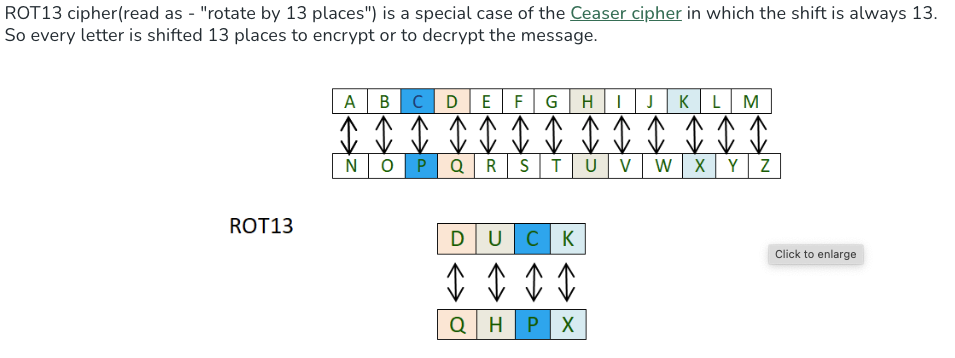

Write two functions:

- `caesar_encrypt(text, shift)`
- `caesar_decrypt(text, shift)`

Rules:

- Only shift letters `A-Z` and `a-z`.
- Preserve case.
- Leave punctuation/spaces unchanged.
- `shift` may be any integer (e.g., 27 should behave like 1).
- You may only use: ord(), chr(), range(), len(), and String methods .isalpha(), .isupper(), and .islower() - look them up. No other functions, methods, or imports.

Example (shift=1): `"Az!"` → `"Ba!"`

Encrypt the phrase "Always look on the bright side of life." with a shift of 13 (called "ROT13")

Decrypt the phase "Guvf cneebg vf ab zber! Vg unf prnfrq gb or! ... Guvf vf na rk-cneebg!" with a shift of 13. Print the output. Then decrypt the output, again with a shift of 13. Print the output.

(6 points available)

```python
# TODO

def caesar_encrypt(text, shift): # defining the function, caesar_encrypt is the name, text and shift are the inputs.
    """Encrypt text using a Caesar cipher with the given shift.""" # docstring explaining what the function does
    result = "" # creates an empty string to store the encrypted text
    for char in text: # loops through the string, one character at a time
        if char.isalpha(): # checks if the character is a letter, enforcing that only letters are encrypted
            base = ord('A') if char.isupper() else ord('a') # decides where the alphabet starts (A or a)
            # char.isupper() checks if the character is uppercase, ord() gets the ASCII value of the character
            encrypted_char = chr((ord(char) - base + shift) % 26 + base) # performs the encryption by shifting the character and wrapping around the alphabet using modulo 26, which is the number of letters in the alphabet
            result += encrypted_char # adds the encrypted character to the result string
        else: # if the character is not a letter
            result += char # non-letter characters are added unchanged because they are not encrypted
    return result # returns the final encrypted string because the function is complete

def caesar_decrypt(text, shift):
    """Decrypt text using a Caesar cipher with the given shift."""
    return caesar_encrypt(text, -shift)

ROT13 = 13 # defining a constant for the ROT13 cipher shift value because ROT13 shifts letters by 13 positions in the alphabet.

encrypted = caesar_encrypt("Always look on the bright side of life.", ROT13) # encrypting the given phrase using ROT13 because it is a common example for Caesar cipher.
print(encrypted)

phrase = "Guvf cneebg vf ab zber! Vg unf prnfrq gb or! ... Guvf vf na rk-cneebg!"

decrypted = caesar_decrypt(phrase, ROT13) # decrypting the given encrypted phrase using ROT13 because it is the reverse operation of encryption.
print(decrypted)

decrypted_again = caesar_decrypt(decrypted, ROT13) # decrypting the decrypted text again to verify that it returns to the original text.
print(decrypted_again)
```

```
Nyjnlf ybbx ba gur oevtug fvqr bs yvsr.
This parrot is no more! It has ceased to be! ... This is an ex-parrot!
Guvf cneebg vf ab zber! Vg unf prnfrq gb or! ... Guvf vf na rk-cneebg!
```

```python
# TESTS (Exercise 6)
assert caesar_encrypt('Az!', 1) == 'Ba!'
assert caesar_encrypt('Hello, World!', 13) == 'Uryyb, Jbeyq!'
assert caesar_decrypt('Uryyb, Jbeyq!', 13) == 'Hello, World!'

msg = 'Seismo-acoustics 101: LP events.'
enc = caesar_encrypt(msg, 27)
assert enc == caesar_encrypt(msg, 1)
assert caesar_decrypt(enc, 27) == msg
```

## Exercise 6 — Loan calculator (functions + dates + loops)

Write a function:

- `loan_summary(principal, annual_rate, monthly_payment, start_date=None)`

It models a loan where:

- `principal` is the starting balance (e.g. 25000.0)
- `annual_rate` is the annual interest rate as a decimal (e.g. 0.06 for 6%)
- interest is charged **daily** at `annual_rate / 365`
- `monthly_payment` is paid **once per month** on the same *day-of-month* as `start_date`

**Default argument requirement**

- If `start_date` is `None`, default it to **today's date**.

**How to simulate** Simulate day-by-day:

1. On each day, first apply daily interest:
   - `balance *= (1 + annual_rate/365)`
2. If that day is a payment day, apply the monthly payment:
   - `balance -= monthly_payment`
   - if payment would overpay, set balance to 0 and stop (paid off)

**Outputs** Your function must:

1. Print the remaining balance at the **end of each calendar year** (Dec 31) while the loan exists.
2. Return a tuple: `(balances_by_year, payoff_date)`, where:
   - `balances_by_year` is a dict like `{2026: 12345.67, 2027: 10111.22, ...}`
   - `payoff_date` is a `datetime.date` when the balance first reaches 0.
3. Print a final message "Your loan will be paid off on " then print the date as YYYY-MM-DD.

**Imports allowed**

- You may `import datetime`.
- No other imports.

Notes:

- If `monthly_payment` is too small (loan never decreases), your simulation should detect this and raise a `ValueError`.
- For simplicity, payments happen on the same day-of-month as `start_date`. If you want bonus points: handle months that don't have that day (e.g. start on the 31st).

Use your loan_summary() function for:

- principal = 100000
- annual_rate = 6/100
- monthly_payment = 2000
- start_date = datetime.date(2026,1,1)

(8 points available)

```python
# TODO
import datetime

def loan_summary(principal, annual_rate, monthly_payment, start_date=None): # define function loan_summary with parameters principal, annual_rate, monthly_payment, and optional start_date
    """Simulate a daily-interest loan with monthly payments. Returns (balances_by_year, payoff_date).
    """ # docstring
    # Your code here

    balance = principal # initialize balance to principal amount because that is the starting loan amount
    daily_rate = annual_rate / 365 # calculate daily interest rate by dividing annual rate by 365 because interest is accrued daily

    if start_date is None: # check if start_date is not provided because we need a starting date for the simulation
        start_date = datetime.date.today() # set start_date to today's date if not provided

    balances_by_year = {} # initialize an empty dictionary to store yearly balances
    current_date = start_date # set current_date to start_date to begin the simulation from the starting date because we need to track the date for payments and yearly records
    pay_day = start_date.day # set pay_day to the day of the month from start_date to determine when monthly payments are made
    first_payment_checked = False # flag to check if the first payment has been processed to ensure the payment is sufficient to reduce the balance

    for _ in range(365*200): # simulate up to 200 years of daily interest accrual and payments because we want to ensure the loan is paid off within a reasonable timeframe

        # Accrue daily interest
        balance *= (1+ daily_rate) # update balance by adding daily interest because interest is accrued daily

        # Monthly payment
        if current_date.day == pay_day: # check if the current day is the payment day to make the monthly payment because payments are made monthly
            before = balance # store balance before payment to check if payment reduces the balance because we need to ensure the payment is sufficient
            balance -= monthly_payment # subtract monthly payment from balance to reduce the loan amount because a payment has been made

            if balance < 0: # check if balance is less than 0 to determine if the loan is paid off because a negative balance indicates overpayment
                balance = 0 # set balance to 0 if it goes negative because the loan cannot have a negative balance
                return balances_by_year, current_date # return yearly balances and payoff date because the loan is fully paid off
            if not first_payment_checked: # check if this is the first payment to validate payment sufficiency because we only need to check this once
                if balance >= before: # check if balance did not decrease after payment to ensure payment is sufficient because the payment must reduce the balance
                    raise ValueError("Monthly payment too low to ever pay off the loan.") # raise error if payment is insufficient
                first_payment_checked = True    # set flag to True after first payment check because we only need to check this once

        # Record yearly balance
        if current_date.month == 12 and current_date.day == 31: # check if current date is December 31st to record yearly balance because we want end-of-year balances
            balances_by_year[current_date.year] = round(balance, 2) # store balance rounded to 2 decimal places for the current year because we want a precise yearly record

        # Advance to next day
        current_date += datetime.timedelta(days=1) # move to the next day to continue the simulation because we are simulating daily interest accrual and payments
    raise ValueError("Loan not paid off within 200 years.") # raise error if loan is not paid off within 200 years to indicate failure to pay off the loan

balances, payoff = loan_summary(
    principal=100000,
    annual_rate=0.06,
    monthly_payment=2000,
    start_date=datetime.date(2026, 1, 1)
) # call the loan_summary function with specified parameters to simulate the loan repayment
print("Balances at year-end:") # print header for yearly balances
for year, balance in balances.items(): # iterate through yearly balances to print them because we want to display the results
    print(year, ":", balance) # print each year and its corresponding balance

print("Your loan will be paid off on", payoff) # print the date when the loan will be fully paid off
```

```
Balances at year-end:
2026 : 81387.54
2027 : 61624.25
2028 : 40649.02
2029 : 18366.81
Your loan will be paid off on 2030-10-01
```

```python
# TESTS (Exercise 6)

def _ref_loan_summary(principal, annual_rate, monthly_payment, start_date):
    import datetime
    balance = float(principal)
    daily_rate = annual_rate / 365.0
    pay_day = start_date.day

    balances_by_year = {}
    d = start_date

    # Basic "never pays off" guard:
    # If after one full month of interest then payment doesn't reduce the balance, it's hopeless.
    # (This is a heuristic but good enough for this homework.)
    # We'll check after first payment.
    first_payment_checked = False

    # We'll simulate up to 200 years to avoid infinite loops
    for _ in range(365 * 200):
        # interest first
        balance *= (1.0 + daily_rate)

        # payment day?
        if d.day == pay_day:
            before = balance
            balance -= monthly_payment
            if balance <= 0:
                balance = 0.0
                # record year-end if payoff is on Dec 31 (handled below), then stop
                payoff_date = d
                return balances_by_year, payoff_date

            if not first_payment_checked:
                # if payment didn't reduce balance, it'll never amortize
                if balance >= before:
                    raise ValueError("Payment too small; balance does not decrease.")
                first_payment_checked = True

        # year-end snapshot
        if d.month == 12 and d.day == 31:
            balances_by_year[d.year] = round(balance, 2)

        d = d + datetime.timedelta(days=1)

    raise ValueError("Simulation exceeded maximum duration.")

# Fixed deterministic test case
import datetime
case_start = datetime.date(2026, 1, 1)
b_ref, payoff_ref = _ref_loan_summary(1000.0, 0.365, 100.0, case_start)

b_student, payoff_student = loan_summary(1000.0, 0.365, 100.0, start_date=case_start)

assert isinstance(b_student, dict)
assert payoff_student == payoff_ref
assert b_student == b_ref
```